[figure not shown]

# **Global Waterpack Analysis - DataCube Implementation**

#### **SDGs4Namibia | Wednesday, 19 May 2021 | 2pm - 4pm CET**

## **Background**

This short notebook demonstrates the difference in workflow and amount of code for a remote sensing analysis, between **a datacube approach** versus **a classic script approach** on a local machine. In this case Michael Wang's (DLR) `Global Waterpack Analysis (GWP)`, computed on his laptop, will be implemented here. The difference in lines of code will be presented during the session.

The GWP is used to derive data for SDG 6.1.

### **Data**

The [Global WaterPack](https://elib.dlr.de/113038/) is a **MODIS** derived product, produced by the German Aerospace Center [(DLR)](https://www.dlr.de/EN/Home/home_node.html). Two years (2013 and 2018) of daily datasets were ingested into the NamibiaCube, covering the whole country via three MODIS-tiles. All datasets contain binary values of 0 and 1:

- 0 - no water (black pixel)
- 1 - water (white pixel)

[figure not shown]

*Figure 1:* Three Global WaterPack tiles covering Namibia. Source: German Aerospace Center (DLR) - [[GWP]](https://elib.dlr.de/113038/).

### **Decisions and Consequences**

This session ties directly into the `Ingestion session` from Wednesday, 12 May 2021.  
Consequences, Alternatives and Learned Lessons from preprocessing steps and YAML definitions will be presented here. The leading talking points will be:

- consequence of the reprojection (EPSG:32733 - WGS 84 / UTM zone 33S) before Ingestion
- induced 0's into the reprojection artefacts
- artefacts in timeseries
- YAML definition: choice of the NAs - is 255 a sensible value?

## **Lets implement Michael's Code**

### **DataCube Connection**

Import the necessary packages and establish a connection to the datacube. This session will be called *'MODIS'*.

```python
import datacube
import pandas as pd
import geopandas as gpd
import matplotlib.pyplot as plt
from odc.ui import with_ui_cbk
from odc.ui import DcViewer
from eo2cube_tools import plot
```

```python
dc = datacube.Datacube(app = 'modis')
```

### **List all ingested and available products**

We are looking for the *'modis_global_waterpack'*, since it contains the ingested MODIS-GWP-tiles.

```python
products = dc.list_products()

display_columns = ["name",
                   "description",
                   "platform",
                   "instrument",
                   "crs",
                   "resolution"]

products[display_columns].sort_index()
```

| id | name | description | platform | instrument | crs | resolution |
| --- | --- | --- | --- | --- | --- | --- |
| 1 | s2_namibia | Sentinel 2 L2A scenes processed, 10, 20 and 60... | SENTINEL_2 | MSI | NaN | NaN |
| 2 | s2_l2a_namibia | Sentinel 2 ARD L2A scenes, EPSG:32734 | SENTINEL_2 | MSI | EPSG:32734 | (-10, 10) |
| 6 | global_waterpack | daily inland surface water extent | MODIS | AQUA_TERRA | NaN | NaN |
| 7 | modis_global_waterpack | daily inland surface water extent, EPSG:32733 | MODIS | AQUA_TERRA | EPSG:32733 | (-250, 250) |

### **List the measurements of *'modis_global_waterpack'***

Calling the measurements will reveal the xarray-dimension, where the binary (water | no water) data is stored - in this case it's *'GWP'*.  
We will call **dataset.gwp** (xarray.dataset) later in this notebook, in order to work with the Global WaterPack values.

```python
product = "modis_global_waterpack"
measurements = dc.list_measurements()
measurements.loc[product]
```

| measurement | name | dtype | units | nodata | flags_definition | aliases |
| --- | --- | --- | --- | --- | --- | --- |
| GWP | GWP | uint8 | 1 | 255 | {'scl': {'bits': [0, 1], 'values': {'0': 'no w... | NaN |

### **Loading shapefile of Namibia**

The shapefile was downloaded from [data.humdata.org](https://data.humdata.org/dataset/namibia-admin-level-1-boundaries).

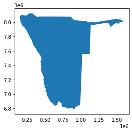

```python
shape = gpd.read_file('shp/nam_admbnda_adm0_nsa_ocha_20200109.shp')
shape = shape.to_crs('epsg:32733')
shape.plot()
```

### **Extract the maximal extents**

In order to limit the area loaded into the dataset, the maximal bounds of the namibian shapefile are extractet here.  
Michael does the same step in theory - with one difference: he uses a shapefile of Namibia in order to reduce the size of his mosaics (produced out of the three GWP-tiles) he created in a previous step, creating another set of intermediate products and an additional function for file-management. This alignes with the nature of local processing, but is completely irrelevant for the usage of a DataCube.

```python
longitude_extents = (shape.total_bounds[0], shape.total_bounds[2])
latitude_extents  = (shape.total_bounds[1], shape.total_bounds[3])

print('\n Maximal shapefile extents:\n\n', 'x:', latitude_extents, '\n y:', longitude_extents, '\n')
```

```
 Maximal shapefile extents:

 x: (6788403.073601587, 8123549.151692053)
 y: (153586.25412708073, 1592441.458974699)
```

### **The way a DataCube is dealing with this**

Instead of mosaicing all three tiles and then clipping them to the size of Namibia, the DataCube tiled all Global Waterpack scenes into predefined tiles (500 x 500 km). So only tiles that the shapefile is touching, will be loaded into the dataset. This is the very reason why the 'tiling-decision' is important during ingestion.

Smaller tiles (lets say 200 x 200 km) would've produced more entries into the database and used a slightly bit more storage space, but would also use less memory space, when loaded into the cube, covering only the necessary area.

```python
DcViewer(dc=dc,
         time='2013-01-01',
         width='1100px',
         center=(-20.00, 27.00),
         zoom=4)
```

### **Loading dataset**

Up to this point, Michael used already about **90 lines of code** in order to achieve a similar result the DataCube is managing with the *dc.load()* function alone. The only difference is the computation of square kilometers of water coverage per dataset, which is convinient to get out of the way at this point. Not doing it would result in producing even more redundant files and another round of file-management.

The majority of his code serves mostly file-management (read & write) of the GWP-GeoTiffs and their intermediate products he produces. Since his way mostly uses storage space and not memory, one can argue this way of analysis is also efficient (for a local machine). But the amount of work is significantly higher.

**IMPORTANT: loading a full year will take about 8 minutes!**

```python
dataset = dc.load(product='modis_global_waterpack',
                  x=longitude_extents,
                  y=latitude_extents,
                  crs='EPSG:32733',
                  time=('2013'),
                  #time = ('2013-01-01', '2013-06-30'),
                  group_by='solar_day',
                  progress_cbk=with_ui_cbk())

#dataset
```

### **Creating an overview of water-pixels over the year 2013**

By creating of a sum of each pixel in a datastack, pixels that have water-information all year around, should reach the maximum value of 365. Depending on how many days per year pixels are representing water, the color-code will change.

The first glance at the *GWP.array()* indicates something not completely correct - values like 93.075 show up. **WHY?**

```python
water_2013 = dataset.resample(time='1Y').sum()
water_2013
```

```
<xarray.Dataset>
Dimensions:      (time: 1, x: 5756, y: 5342)
Coordinates:
  * time         (time) datetime64[ns] 2013-12-31
  * y            (y) float64 8.124e+06 8.123e+06 ... 6.789e+06 6.788e+06
  * x            (x) float64 1.536e+05 1.539e+05 ... 1.592e+06 1.592e+06
    spatial_ref  int32 32733
Data variables:
    GWP          (time, y, x) uint64 365 365 365 365 ... 93075 93075 93075 93075
```

### **Lets plot the result and see for ourselves**

Plotting the result reveals the problem, which goes way back to the ingestion process. Remember this **YAML**-snippet?

[figure not shown]

*Figure 2:* Namibia Workshop Slides - Day 1 | Afternoon Session. Source: check our [[Github repository]](https://github.com/eo2cube/namibia_workshop/blob/main/presentation_slides/02_SDGs4Namibia_ingestion_kluter.pdf).

By definition during ingestion, all appearing 'no data' values will receive an assignment 255. The extend of the namibian shapefile includes areas which are not covered by MODIS-scenes. By default, this eastern strip will receive only values of 255.

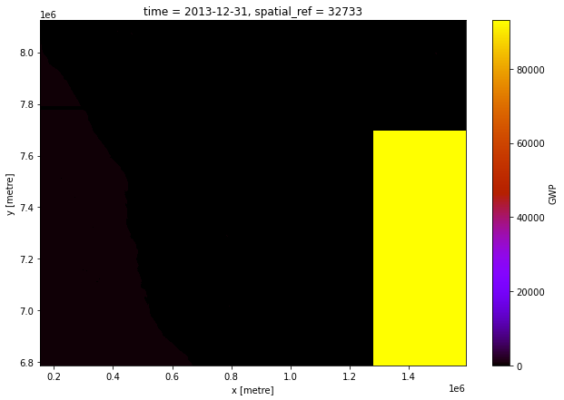

```python
water_2013.GWP.plot(size=7, cmap="gnuplot")
```

### **Other ways**

Since the 255 assignment is set in stone (at least until you reingest), there must be another way to solve this.

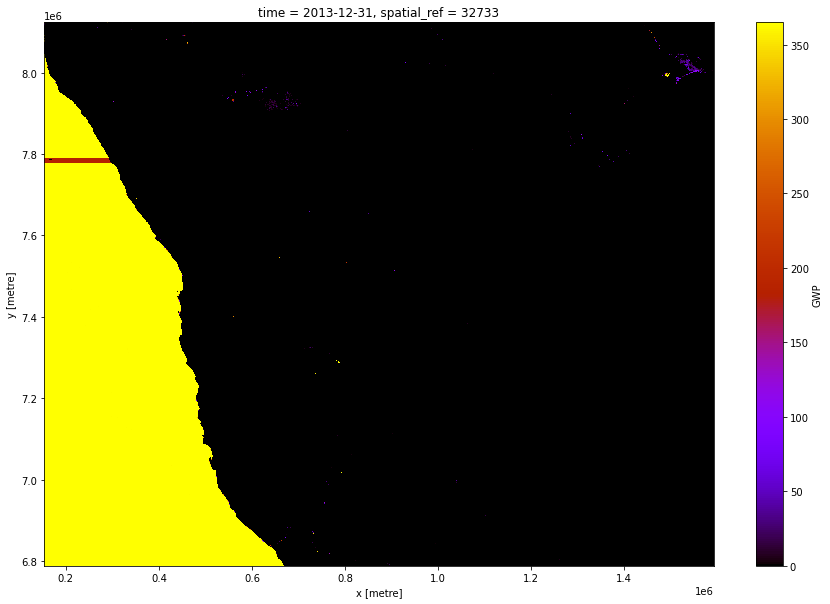

```python
dataset_resampled = dataset.where(dataset <= 254, 0)
water_2013 = dataset_resampled.resample(time='1Y').sum()
water_2013.GWP.plot(size=10, cmap="gnuplot")
```

### **First Result**

This loos like a reasonable result. You will notice a red horizontal line in the left upper corner. The color code suggests a value somewhere around 180. This artefact is a remnant from a reprojection that was performed on the GWP-MODIS-Tiles before ingestion. Through a slight shift within the new projection, the stripe over the ocean received induced 0-values. So if you sum an overlapping area with 365 1-values and another 365 0-values on top, you will average out somewhere around 182.

`((1 * 365) + (0 * 365)) / 2 = 182.5`

Overall, the DataCube got to the same result - via a little detour - in only **four functions**, mostly one-liners. It took Michael **over 100 lines of code** in order to achieve the equivalent.

### **Clean Dataset**

It can't hurt to mask out any other outside the shapefile of Namibia. This way, every other calculation will stay inside the national border of the country.

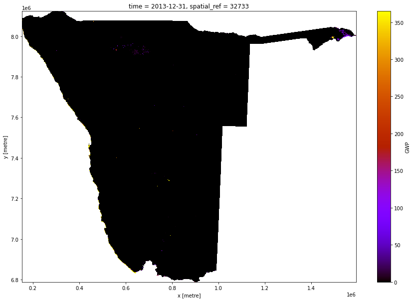

```python
from dea_tools.spatial import xr_rasterize

mask = xr_rasterize(shape, water_2013)
data_masked = water_2013.where(mask)
data_masked.GWP.plot(size=10, cmap="gnuplot")
```

### **Quick Impression of the average water covered km²**

Just to make sense of the amount of the water covered areas (in km²) we are dealing with, an average for the whole year 2013 is calculated. Likely, it has no real scientific significance. It's supposed to be an impression of the water dimensions in a country of this size.

In this case we get an average area of 617 km² covered with water in the year 2013.

```python
(data_masked.GWP.sum() * 250 * 250 / 1000000) / 365
```

```
<xarray.DataArray 'GWP' ()>
array(617.4739726)
Coordinates:
    spatial_ref  int32 32733
```

### **Workshop Challange | RAM Problems**

To draw the same masked and cleaned graph as Michael did in the final Namibia Tech Meeting, it takes only to mask every daily dataset **(see commented notebook cell)**. Unfortunately, here we run into memory issues. *xr_rasterize()* seems to copy the whole dataset into the RAM in order to clip it. It fills up all the available memory and the kernel dies.

But there are other ways to do it.

#### **Today every workshop attendee is encouraged to put his/her newly gained expertise to the test.**

```python
#mask = xr_rasterize(shape, dataset_resampled)
#data_masked = dataset_resampled.where(mask)
#data_masked.GWP.plot(size=10, cmap="gnuplot")
```

### **Proof of Concept**

Since we do have a loaded dataset anyway, we can at least proceed and show the relative behaviour of such graph is over the year:

- the large water covered area / pixels (330.000 km²) is due to the presence of the ocean within the dataset.
- a large oscillation is most likely due to the same reason. Another test is required to confirm this.
- the relative graph is precisely (upper und bottom "line") is exactly as Michael showed it in his results.

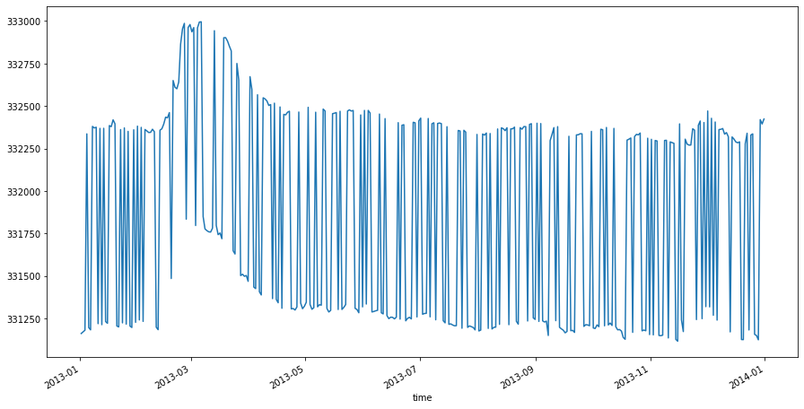

```python
water_area = dataset_resampled.sum(dim = ('x', 'y')).to_dataframe()
water_area['extent'] = ((water_area['GWP'] * 250 * 250) / 1000000)
water_area.extent.plot(figsize=(15,8))
```

### **Testing the Oscillation**

Ocean pixels are most likely to be responsible for the spikes in the previous graph. The idea is to test this theory on a smaller dataset that we can clean up. In the xarray-session on Day 3 (morning session) Kemeng showed how to subset a full dataset.

We choose to subset February:

```python
dataFEB = dataset_resampled.sel(time='2013-02').to_array().rename({"variable":"band"})
dataFEB = dataFEB.to_dataset(dim="band")
dataFEB
```

```
<xarray.Dataset>
Dimensions:      (time: 28, x: 5756, y: 5342)
Coordinates:
  * time         (time) datetime64[ns] 2013-02-01T11:39:34.116000 ... 2013-02...
  * y            (y) float64 8.124e+06 8.123e+06 ... 6.789e+06 6.788e+06
  * x            (x) float64 1.536e+05 1.539e+05 ... 1.592e+06 1.592e+06
    spatial_ref  int32 32733
Data variables:
    GWP          (time, y, x) uint8 1 1 1 1 1 1 1 1 1 1 ... 0 0 0 0 0 0 0 0 0 0
Attributes:
    crs:           EPSG:32733
    grid_mapping:  spatial_ref
```

### **Masking the Subset**

We try to mask the namibian shape only on this subset:

```python
mask = xr_rasterize(shape, dataFEB)
data_masked = dataFEB.where(mask)
```

### **Lets retry the Graph**

It works like intended!

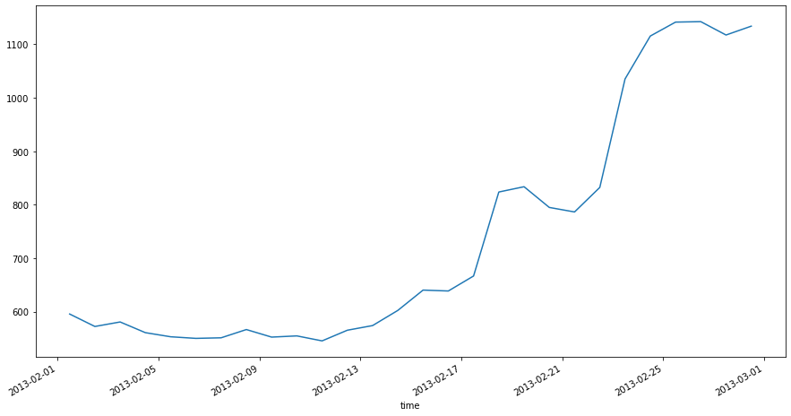

```python
water_area = data_masked.sum(dim = ('x', 'y')).to_dataframe()
water_area['extent'] = ((water_area['GWP'] * 250 * 250) / 1000000)
water_area.extent.plot(figsize=(15,8))
```

# **Global Waterpack Challenge**

[figure not shown]

#### **As this workshop is coming to an end, we prepared two challenges for you (if you are up for the task).**

**> EASY:**

**The `oanob_dam.shp` is placed in `../kluter/shp/`**

- Try to recreate the GWP Analysis on this small area - create graph and a map for both available years (2013 and 2018).
- Calculate the difference between the two years.

**>> PROFICIENT:**

- Try to solve the RAM issue, and produce a clean graph for the whole year 2013 or 2018.
- Look up the available Notebooks, there will likely be a method suited for the task.